# Indian Economy: Privatisation and Innovation

### Lecture by Dr. Baswanth Oruganti

### Research Question

How India can acheive high economic growth rate and become a developed economy ?

### Research Methodology

1. Descriptive Statistical Analysis based on the World Bank Data
2. Inferential Statistical Analysis based on well-known economic models

# OUTLINE

1. Introduction to GDP
2. Results and Discussion
   - India's GDP and GDP growth rate
   - How India can achieve high GDP growth rate?
   - A case study of Nokia
3. Conclusions
4. References

# Introduction to GDP

## What is Gross Domestic Product (GDP) ?

- A measure of value of all goods and services produced in a country
- Reflects economic activity
- Calculating GDP: 3 different Ways (Production, Income, Expenditure)

## Nominal vs. Real GDP

- Nominal GDP: GDP at current prices
- Real GDP: GDP at constant prices relative to a base year
- Example: Consider increase in Petrol prices in 2020 and 2021
- Real GDP = Nominal GDP - Inflation
- When govt. says 5 trillion dollar GDP one should ask whether nominal or real

## GDP in itself is not very representative of the economy

## Per Capita GDP

- Large population means large GDP
- Use Per Capita GDP = ${\frac{\text{GDP}}{\text{Population}}}$

## Per Capita GDP Purchasing Power Parity (PPP)

- Purchasing power parity: Accounts for difference in prices in different countries
- Example:
  1. Buying 1 Kg rice in Sweden (25 SEK) vs. India (50 INR)
  2. Renting Apartment in Sweden (7000 SEK) vs. India (14000 INR)
- A measure of effective exchange rate for an individual

# Results and Discussion

## India's GDP

- ~2.9 Trillion USD in 2019
- Third largest GDP (PPP) (China ranks 1, US ranks 2)
- India ranks 124 th in per capita GDP (PPP) (US: 7, China: 73, Germany: 15, Sweden: 16)
- Purchasing power of individuals is very less in India and China compared to US, Sweden or Germany
- Poverty due to underemployment (low paid and low skill jobs)

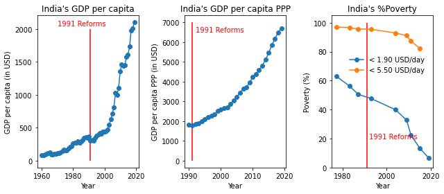

```python
df=pd.read_csv("gdp_per_capita.csv",header=None,skiprows=1)
df1=pd.read_csv("GDP_ppp_percapita.csv",header=None,skiprows=1)
df2=pd.read_csv("poverty.csv")

fig, ax = plt.subplots(1,3,figsize=(9,4))
ax[0].plot(df[0],df[1],marker="o")
ax[0].set_xlabel("Year")
ax[0].set_ylabel("GDP per capita (in USD)")
ax[0].set_title("India's GDP per capita")
ax[0].vlines(ymin=0,ymax=2000,x=1991, color='red')
ax[0].annotate("1991 Reforms", xy=(1970,2050), color='red')

ax[1].plot(df1[0],df1[1],marker="o")
ax[1].set_xlabel("Year")
ax[1].set_ylabel("GDP per capita PPP (in USD)")
ax[1].set_title("India's GDP per capita PPP")
ax[1].vlines(ymin=0,ymax=7000,x=1991, color='red')
ax[1].annotate("1991 Reforms", xy=(1992,6500), color='red')

ax[2].plot(df2['Year'],df2['extreme_poverty'],marker="o")
ax[2].plot(df2['Year'],df2['poverty'],marker="o")
ax[2].set_xlabel("Year")
ax[2].set_ylim([0,105])
ax[2].set_ylabel("Poverty (%)")
ax[2].set_title("India's %Poverty")
ax[2].legend(['< 1.90 USD/day','< 5.50 USD/day'],loc=(0.15,0.6),frameon=False)
ax[2].vlines(ymin=0,ymax=100,x=1991, color='red')
ax[2].annotate("1991 Reforms", xy=(1992,20), color='red')
plt.tight_layout()
plt.savefig("Fig1.eps",dpi=600)
```

## India's GDP growth rate

GDP growth rate = $\frac{\Delta G}{G}$

Mean growth rate from 1960-1990: 4.2%

Mean growth rate from 1991-2019: 6.4%

- Why large fluctuations in growth rate (sustainability is less)?

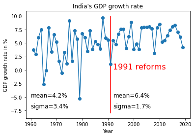

```python
df3=pd.read_csv("gdp_growth.csv",header=None,skiprows=1)
fig, ax = plt.subplots(figsize=(6,4))

ax.plot(df3[0],df3[1],marker="o")
ax.set_xlabel("Year"); plt.ylabel("GDP growth rate in %")
ax.annotate("1991 reforms", xy=(1992,0.2),size=16,color='red')
std1=df3[1][1:30].std(); std2=df3[1][31:].std(); avg1=df3[1][1:30].mean();avg2=df3[1][31:].mean()
ax.vlines(ymin=-8,ymax=10,x=1991, color='red'); ax.set_title("India's GDP growth rate")
ax.annotate(f"sigma={round(std1,1)}%", xy=(1960,-7),size=12);
ax.annotate(f"sigma={round(std2,1)}%", xy=(1992,-7),size=12)
ax.annotate(f"mean={round(avg1,1)}%", xy=(1960,-5),size=12);
ax.annotate(f"mean={round(avg2,1)}%", xy=(1992,-5),size=12)
plt.savefig("Fig2.eps",dpi=600)
plt.show()
```

## How can India can achieve high GDP growth rate ?

GDP growth rate $ = \frac{\Delta G}{G} = \frac{\Delta K}{G} * \frac {\Delta G}{\Delta K}$ = $ \text {investment-GDP ratio} * \eta $

2 factors:

1. $\Delta K$ is increase in capital investment in a given year
2. $ \eta $ is efficiency of capital use

### How government policies influence $\Delta{K}$ ?

$${\Delta K}=\Delta{K_{private}} + \Delta{K_{public}} $$

- Private investment: Spending your money for your company (more responsibility)
- Public investment: Giving your money to govt. who gives it to someone else for spending (less reponsibility)
- Limitations of public investment:
1. High Public Investment Means Heavy Taxes on Poor and Middle Class
2. Inefficient
3. Corruption and Favoritism
- Drawbacks of private investment:
1. Labor Exploitation (శ్రమ దోపిడీ)
2. Lack of employee welfare

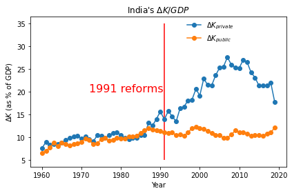

```python
invest=pd.read_csv("capital_investment_innovation.csv")
invest=invest.fillna(0)
fig, ax = plt.subplots(figsize=(6,4))
ax.plot(invest['Year'],invest['dKprivate'],marker="o")
ax.plot(invest['Year'],invest['dKpublic'],marker="o")
ax.set_xlabel("Year")
ax.set_ylabel(r'$\Delta{K}$ (as % of GDP)')
ax.set_title("India's $\Delta{K}/GDP$")
ax.vlines(ymin=5,ymax=35,x=1991, color='red')
ax.annotate("1991 reforms", xy=(1972,20),size=16,color='red')
ax.legend([r'$\Delta{K_{private}}$',r'$\Delta{K_{public}}$'],loc=(0.6,0.8),frameon=False)
plt.tight_layout()
plt.savefig("Fig3.eps",dpi=600)
```

### How government policies influence ${\eta}$ ?

#### Exogeneous Economic Growth Model

- Developed by Prof. Robert Solow (1981 Nobel Memorial Prize in Economics)
- GDP growth rate is limited by Law of diminishing marginal returns
- Only 35 % growth is due to ${\Delta K}$; 65% growth rate is due to $\eta$ (which is a function of innovation)
- Innovation is essential to increase $\eta$
- But considered as an external factor of the economic model

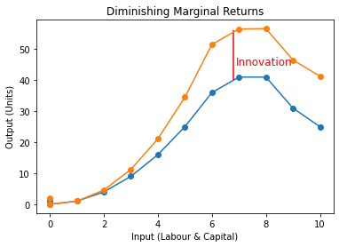

```python
dim=pd.read_csv("diminish.csv",header=None)
fig, ax = plt.subplots(figsize=(6,4))

ax.plot(dim[0],dim[1],marker="o")
ax.plot(dim[0],dim[2],marker="o")
ax.set_xlabel("Input (Labour & Capital)")
ax.set_ylabel("Output (Units)")
ax.annotate("Innovation", xy=(6.9,45), color='r',size=12)
ax.set_title("Diminishing Marginal Returns")
ax.vlines(ymin=40,ymax=56,x=6.8, color='red')
plt.savefig("Fig4.eps",dpi=600)
plt.show()
```

### How government policies influence ${\eta}$ ?

#### Endogeneous Economic Growth Model

- Prof. Michael Romer (2018 Nobel Memorial Prize in Economics, former IMF president)
- Integrates innovation into exogeneous economic model

### $$\eta = \eta_{business} + \eta_{tech}$$

1. $\eta_{business}$: Jio, Patanjali, Vivo/Oppo (short-term)
2. $\eta_{tech}$: Aeroplane, Computer, Internet, Social Networking, ML, AI, Genomics, Quantum Computers (long-term)
- Sustainable economic growth possible by increasing incentive for sceintific innovation by spending more on education and R&D
- India's spending on R & D is only 0.6-0.8 % of GDP, China spends 2.1%, US spends 2.8%, Israel spends 4.3%

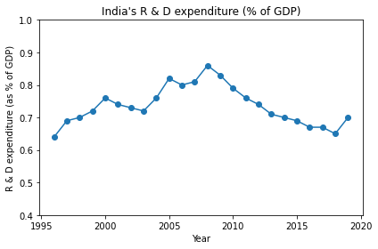

```python
fig, ax = plt.subplots(figsize=(6,4))
ax.plot(invest['Year'][36:],invest['R&D'][36:],marker="o")
ax.set_xlabel("Year")
ax.set_ylabel(r"R & D expenditure (as % of GDP)")
ax.set_ylim([0.4,1.0])
ax.set_title("India's R & D expenditure (% of GDP)")
plt.tight_layout()
plt.savefig("Fig5.eps",dpi=600)
```

## Case Study: The Rise and Fall of Nokia

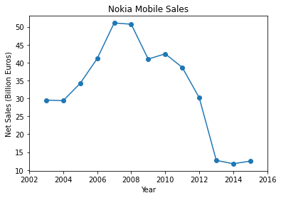

```python
df3=pd.read_csv("nokia.csv",header=None,skiprows=1)
fig, ax = plt.subplots(figsize=(6,4))

ax.plot(df3[0],df3[1],marker="o")
ax.set_xlabel("Year")
ax.set_ylabel("Net Sales (Billion Euros)")
ax.set_title("Nokia Mobile Sales")
plt.savefig("Fig6.eps",dpi=600)
plt.xlim(2002,2016)
plt.show()
```

# Conclusions

1. Increase private investment ($\Delta{K_{private}}$) by tax incentives to corporates that follow optimal wage policies/employee welfare
2. Minimize government investment ($\Delta{K_{public}}$): income tax can be abolished and taxes on fuel can be decreased (Dr. Swamy's advice)
3. Increase Business Innovation ($\eta_{business}$) by privatisation
4. Foster Scientific Innovation ($\eta_{tech}$) by huge government spending (6% of GDP) on Education, Health and R&D.

# Final Thoughts

1. "Government must be an umpire not a player of the game" - Milton Friedman
2. "Socialism means a large government, and a large government means heavy taxation that kills incentive for hard work." -Subramanian Swamy
3. "The only way to achieve equity in India is to create adequate employment and ensure certain minimum amenities (like housing and transportation) for those employed. The taxation system should be used as an instrument to give incentives to capitalists for providing all these facilities" -Subramanian Swamy

# References

```
1. GDP Data source: World Bank
2. RESET: Regaining India's Econmic Legacy by Subramnian Swamy (former Professor at Harvard University)
3. Capitalism and Freedom by Milton Friedman (American Economist)
```